# Data Visualization Analysis

## 4 Bar chart with color

### 4.1 Basic Bar Chart Colors

The simplest way to add colors to a bar chart is by using the `fill` function, and to add color in the outline use the `colour` function inside the `geom_col`

Example using the `cabbage_exp`dataset

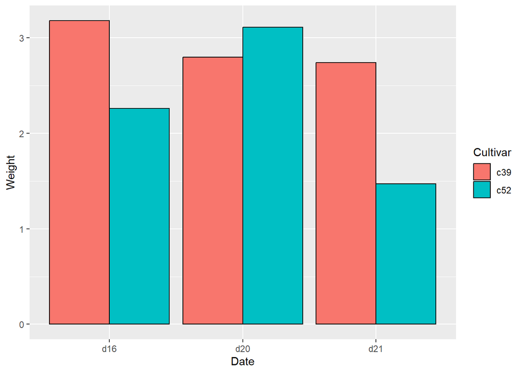

```r
ggplot(cabbage_exp, aes(x = Date, y = Weight, fill = Cultivar)) +
  geom_col(colour = 'black',
           position = 'dodge')
```

- The color is set as default when using fill
- `geom_col(colour = 'black')`: This add colour to the outline

To manually adjust the color, use `scale_fill_manual`.

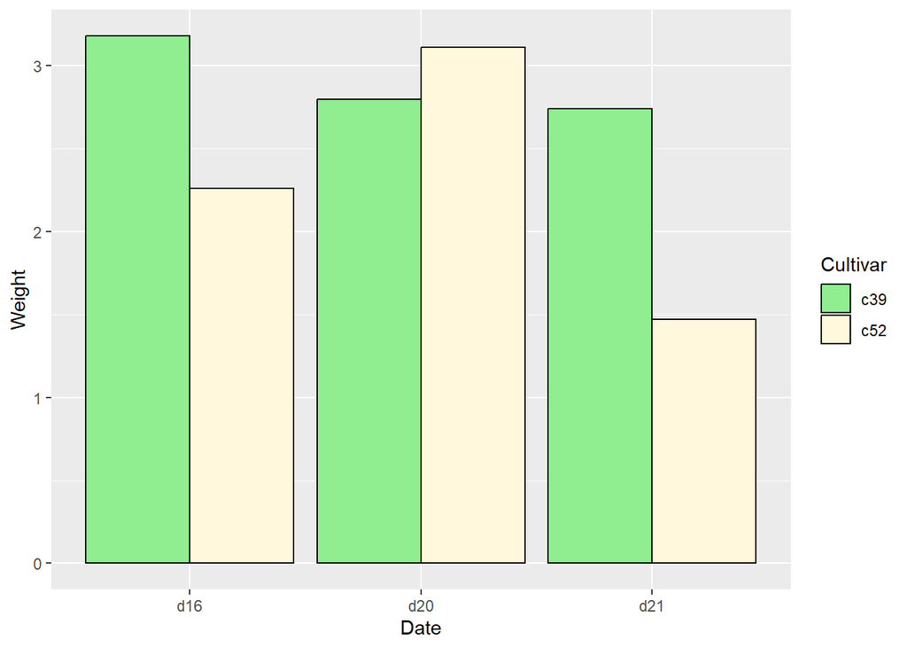

```r
ggplot(cabbage_exp, aes(x = Date, y = Weight, fill = Cultivar)) +
  geom_col(colour = 'black',
           position = 'dodge')+
  scale_fill_manual(values = c('lightgreen', 'cornsilk'))
```

- `scale_fill_manual(values = c('lightgreen', 'cornsilk'))`: Manually chose the color to add
  - Hex codes are also available, to manually mix the colors (Ex. `#FF5733`)

### 4.2 Transparancy Of the Bar Chart

Use `alpha` to change the transparency of the filled color.

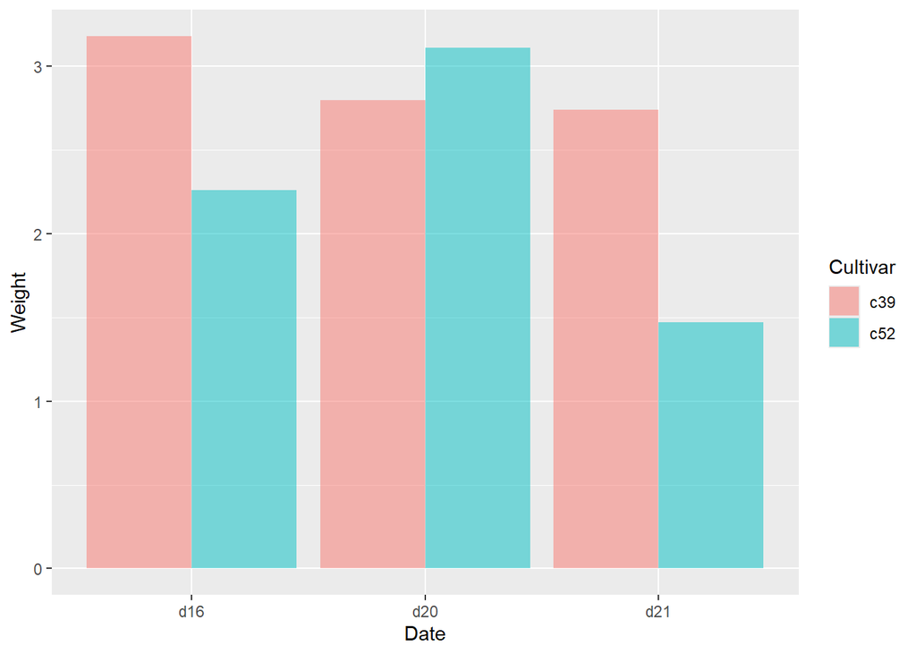

```r
ggplot(cabbage_exp, aes(x = Date, y = Weight, fill = Cultivar)) +
  geom_col(alpha = 0.5,
           position = 'dodge')
```

- `geom_col(alpha = 0.5)`: Changes the transparency of the bar graph

### 4.3 Coloring Negative and Positive Bars

This bar chart shows how to use different colors for positive and negative values.

An example using the `climate` dataset

```r
head(climate, 5)
```

```
    Source Year Anomaly1y Anomaly5y Anomaly10y Unc10y
1 Berkeley 1800        NA        NA     -0.435  0.505
2 Berkeley 1801        NA        NA     -0.453  0.493
3 Berkeley 1802        NA        NA     -0.460  0.486
4 Berkeley 1803        NA        NA     -0.493  0.489
5 Berkeley 1804        NA        NA     -0.536  0.483
```

In order to color values differently, first we define which values to differentiate

```r
library(dplyr)
filtered_climate <- climate %>%
  filter(Source == 'Berkeley' & Year >= 1900) %>%
  mutate(NegorPos = Anomaly10y >= 0)

head(filtered_climate,5)
```

```
    Source Year Anomaly1y Anomaly5y Anomaly10y Unc10y NegorPos
1 Berkeley 1900        NA        NA     -0.171  0.108    FALSE
2 Berkeley 1901        NA        NA     -0.162  0.109    FALSE
3 Berkeley 1902        NA        NA     -0.177  0.108    FALSE
4 Berkeley 1903        NA        NA     -0.199  0.104    FALSE
5 Berkeley 1904        NA        NA     -0.223  0.105    FALSE
```

- `library(dplyr)`: library for the filter and mutate function
- `filter(Source == 'Berkeley' & Year >= 1900)` : filter for only Berkeley and year 1900 and above
- `mutate(NegorPos = Anomaly10y >= 0)` : Makes a new column to differentiate between positive and negative

Having negative value and positive value differentiated, simply use `fill` function to color

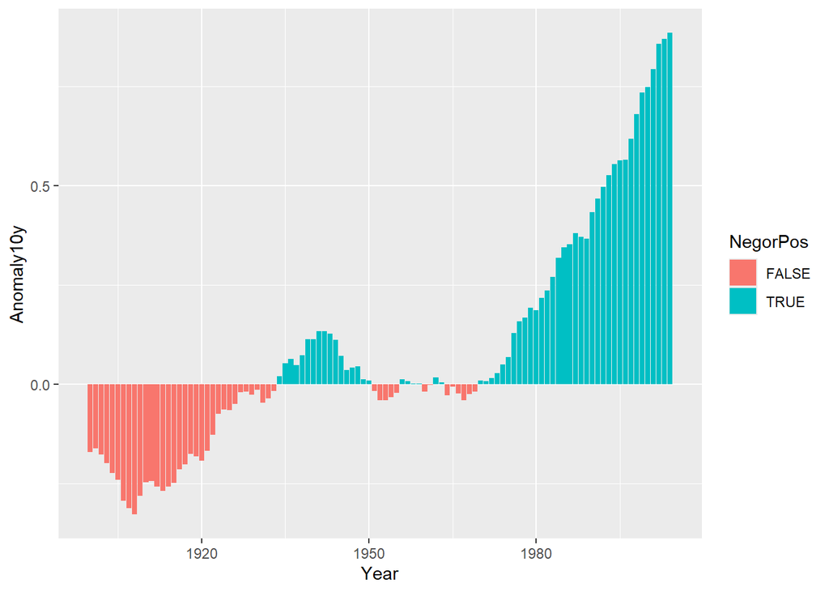

```r
ggplot(filtered_climate, aes(x = Year, y = Anomaly10y, fill = NegorPos)) +
  geom_col(position = 'identity')
```

## 5 Line chart

A line Chart is used to visualize trends or changes over a continuous variable, typically time, making it ideal for tracking time-series data or analyzing relationships between variables. It is especially effective for identifying trends, comparing categories, or highlighting patterns in data.

### 5.1 Making a Basic Line Chart

Using the `ggplot2` library, the `geom_line` creates a line graph

Here is an example using the `BOD` dataset

```r
BOD
```

```
  Time demand
1    1    8.3
2    2   10.3
3    3   19.0
4    4   16.0
5    5   15.6
6    7   19.8
```

Graphing the line chart

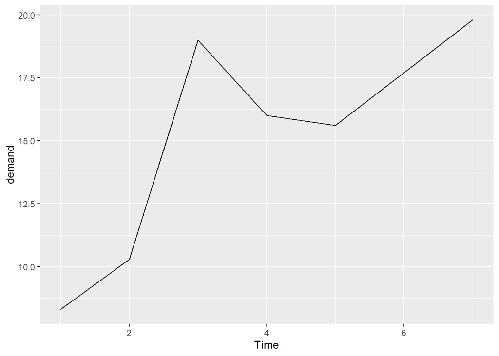

```r
ggplot(BOD, aes(x = Time, y = demand)) +
  geom_line()
```

- `aes(x = Time, y = demand)`: Assigns Time (X-axis) and demand (Y-axis).
- `geom_line()`: Creates a line chart where the X axis is a continuous numeric variable, and Y-axis as a dependent variable.

### 5.2 Adding Points to a Line graph

`geom_point` is used to add points to a line graph.

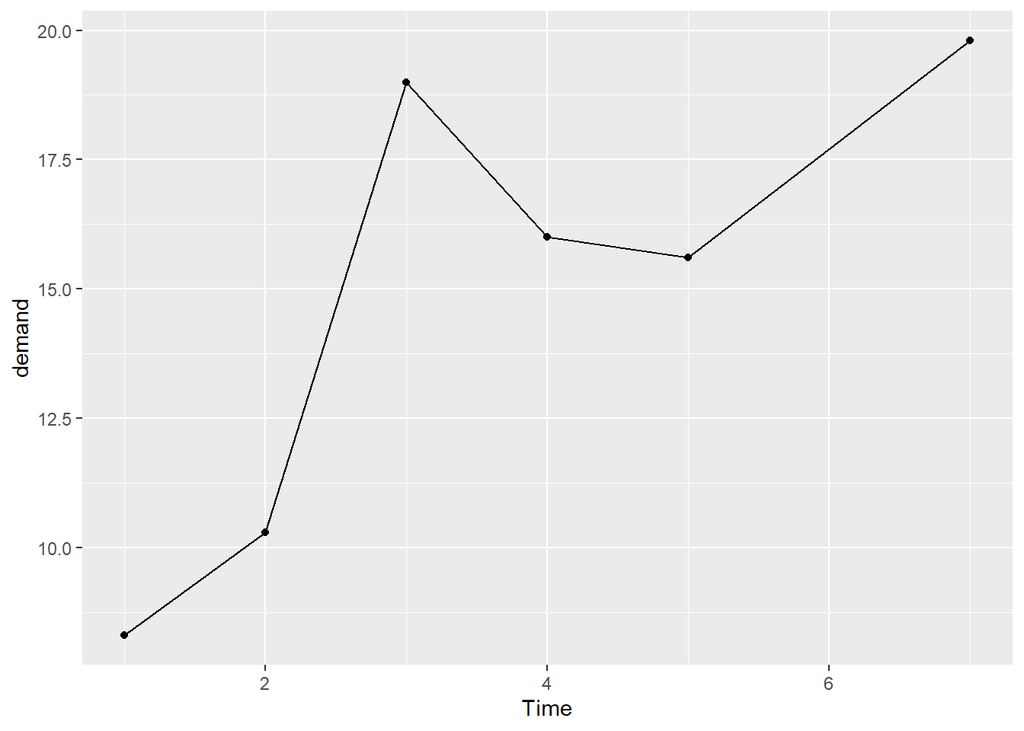

```r
ggplot(BOD, aes(x = Time, y = demand)) +
  geom_line()+
  geom_point()
```

### 5.3 Multiple Line, Line Chart

Making a line graph with more than one line

An example using the `tg` dataset

```r
tg
```

```
  supp dose length
1   OJ  0.5  13.23
2   OJ  1.0  22.70
3   OJ  2.0  26.06
4   VC  0.5   7.98
5   VC  1.0  16.77
6   VC  2.0  26.14
```

- in addition to `dose` and `length`, there is an extra variable `supp`.

Graphing the line chart

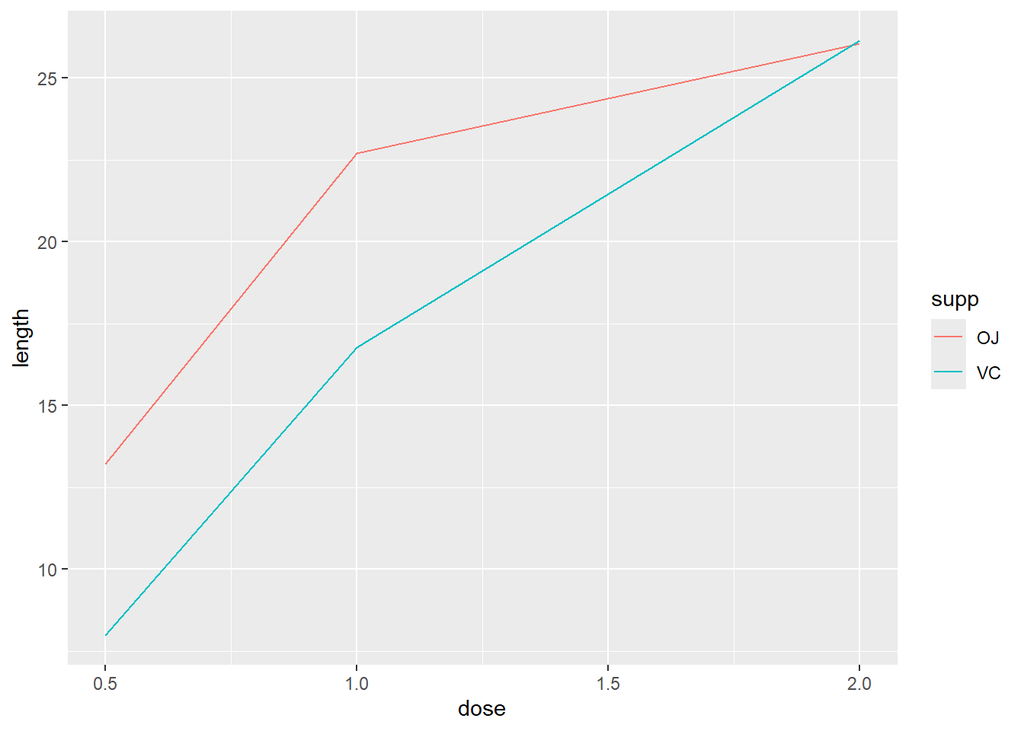

```r
ggplot(tg, aes(x = dose, y = length, colour = supp)) +
  geom_line()
```

- `aes(x = dose, y = length, colour = supp))`: this fuctions allows the extra variable to be differenciated using a different colored line.

### 5.4 Appearance of Line and Points

Using `linetype` and ‘Shape’ allows to change the type of lines and point

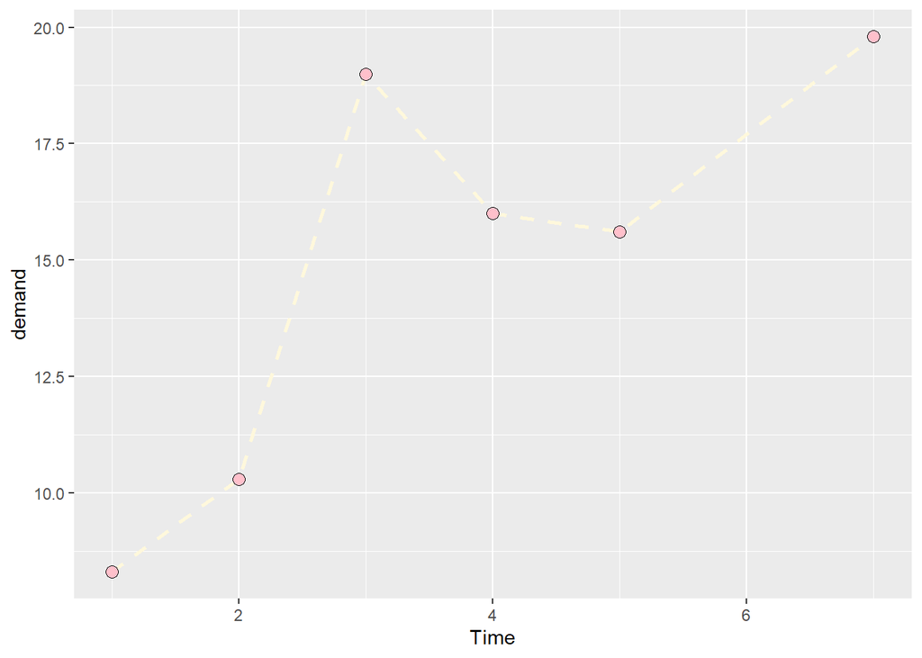

```r
ggplot(BOD, aes(x = Time, y = demand)) +
  geom_line(linetype = 'dashed', linewidth = 1, colour = 'cornsilk') +
  geom_point(size = 3, shape = 21, fill = 'pink')
```

- `geom_line(linetype = 'dashed', linewidth = 1, colour = 'cornsilk')`:
  - `linetype`: change the type of line
  - `linewidth`: change the size of line
  - `colour`: change the color of the line
- `geom_point(size = 3, shape = 21, fill = 'pink')`:
  - `size`: change the size of point
  - `shape`: change the type of shape of the point
  - `fill`: fill the point with chosen color.

## 6 Histogram

A Histogram is used to visualize the distribution of a continuous numerical variable by grouping data into intervals (bins) and displaying the frequency of observations in each bin. It helps identify patterns such as skewness, modality, or the presence of outliers in the dataset.

### 6.1 Making Basic Histogram

Here is an example using the `faithful` dataset

```r
head(faithful, 5)
```

```
  eruptions waiting
1     3.600      79
2     1.800      54
3     3.333      74
4     2.283      62
5     4.533      85
```

- `faithful` dataset has two columns: `eruption`, `waiting`. Where it shows a relationship between eruption duration and waiting time

Graphing the Histogram

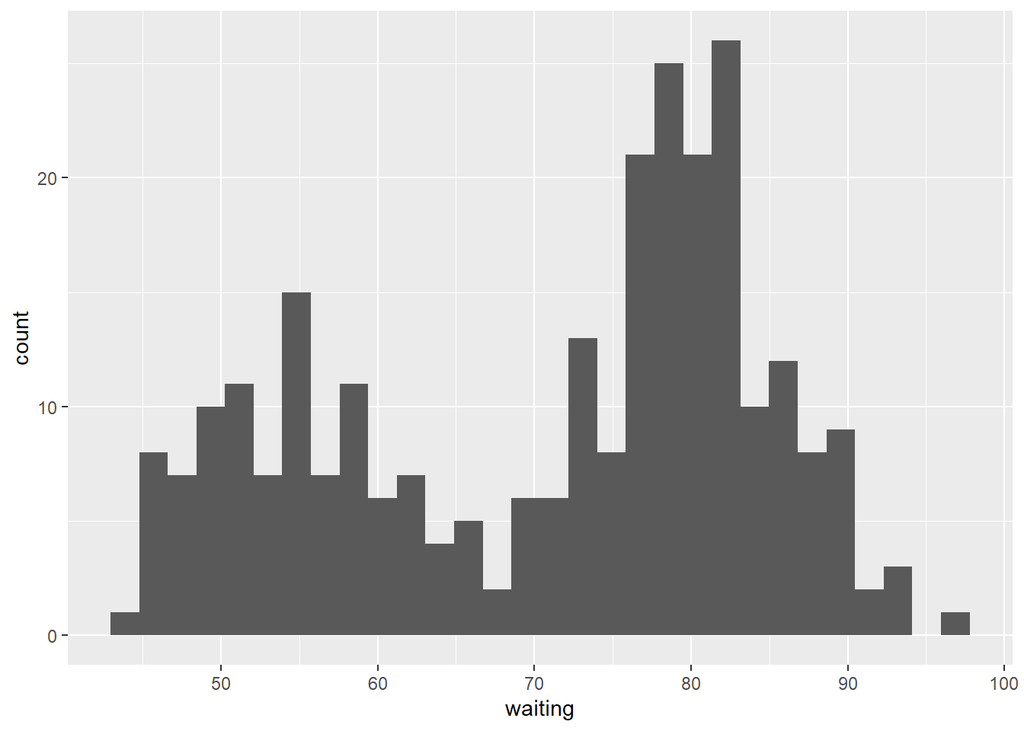

```r
ggplot(faithful, aes(x = waiting)) +
  geom_histogram()
```

- `aes(x = waiting)`: All a histogram needs is a single vector of data. In this case the time as `waiting`.
- `geom_histogram()`: Creates a histogram, where X-axis represents a continuous numeric variable divided into bins, and the Y-axis represents the count of observations within each bin.

### 6.2 Customizing Histogram

Changing the size of the bin manually.

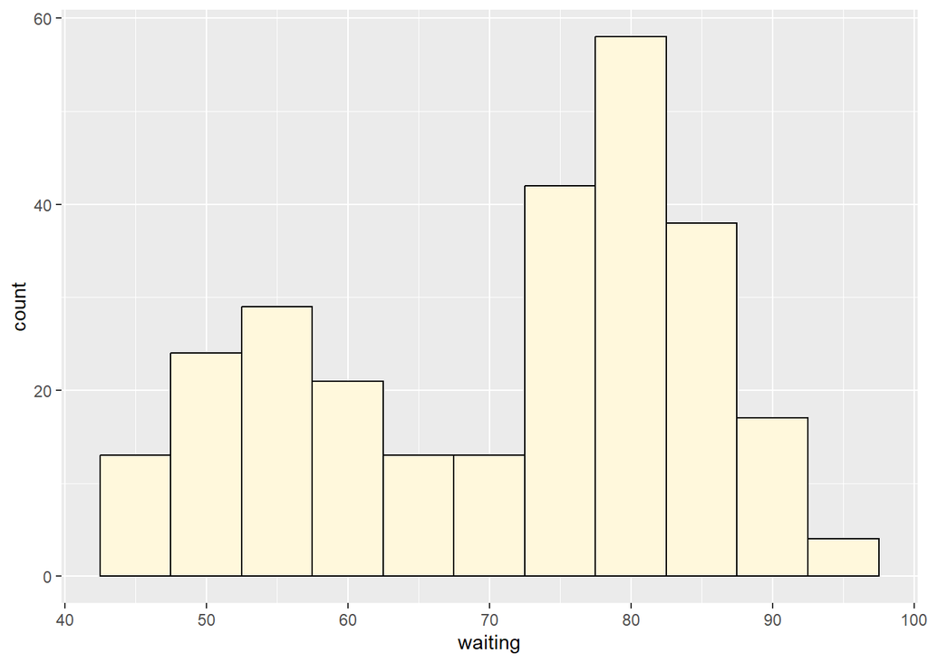

```r
ggplot(faithful, aes(x = waiting)) +
  geom_histogram(binwidth = 5, fill = 'cornsilk', colour = 'black')
```

- `geom_histogram(binwidth = 5)`: The binwidth argument sets the width of each bin to 5 units, meaning the X-axis is divided into bins of equal size, each spanning 5 units.

Calculating the Bin Width Based on the Data Range

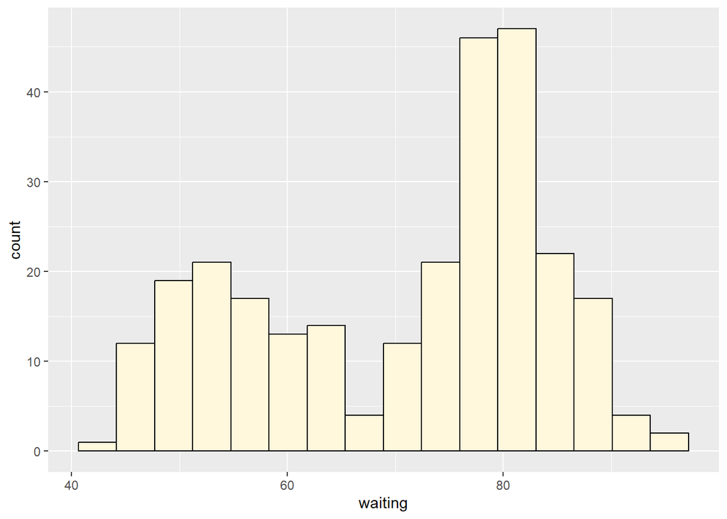

```r
bin <- diff(range(faithful$waiting))/15

ggplot(faithful, aes(x = waiting)) +
  geom_histogram(binwidth = bin, fill = 'cornsilk', colour = 'black')
```

- `range(faithful$waiting)`: This calculates the range of the waiting variable
- `diff()`: Computes the difference between the maximum and minimum values, giving the total range.
- `geom_histogram(binwidth = bin)`: Sets the bin width to the calculated value

## 7 Multigroup Histogram

A multigroup histogram used to compare the distributions of a numerical variable across different levels of a categorical variable. By displaying separate histograms for each group.

Example using the `birthwt` dataset

```r
library(MASS)
head(birthwt,5)
```

```
   low age lwt race smoke ptl ht ui ftv  bwt
85   0  19 182    2     0   0  0  1   0 2523
86   0  33 155    3     0   0  0  0   3 2551
87   0  20 105    1     1   0  0  0   1 2557
88   0  21 108    1     1   0  0  1   2 2594
89   0  18 107    1     1   0  0  1   0 2600
```

- The data above shows the non smoker and smoker, on the smoke category, but a problem with multigroup histogram is that the labels for smokers is indicated by 1 and 0. Now we need to label it accordingly

The next example will show how to change label the smoke variable by changing the names of the factor labels

```r
birthwtchanged <- birthwt
birthwtchanged$smoke <- recode_factor(birthwtchanged$smoke, '0'='No Smoke', '1'= "Smoke")
```

- `birthwtchanged <- birthwt`: making a copy of the old dataset with a new name
- `recode_factor(birthwtchanged$smoke, '0'='No Smoke', '1'= "Smoke")`: recodes the value of (0 and 1) with meaningful labels (“No Smoke” and “Smoke”).

Graphing using the modified dataframe

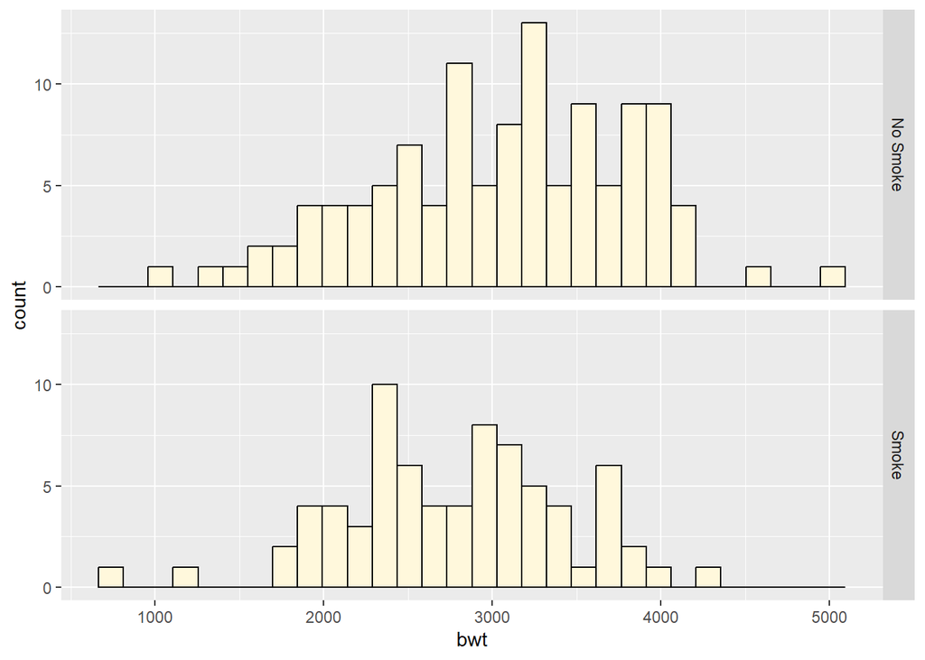

```r
ggplot(birthwtchanged, aes(x = bwt)) +
  geom_histogram(fill = 'cornsilk', colour = 'black') +
  facet_grid(smoke ~ .)
```

A correlation chart is a visual representation that shows the relationship between two or more variables.

### 7.1 Scatter Plots

A scatter plot is used to visualize the relationship between two continuous variables by displaying data points on a two-dimensional graph. It helps identify trends, correlations, and patterns, such as linear, nonlinear, or no correlation between the variables.

Here is an example using the `heightweight` dataset

```r
head(heightweight, 5)
```

```
  sex ageYear ageMonth heightIn weightLb
1   f   11.92      143     56.3     85.0
2   f   12.92      155     62.3    105.0
3   f   12.75      153     63.3    108.0
4   f   13.42      161     59.0     92.0
5   f   15.92      191     62.5    112.5
```

- `heightweight` dataset, which includes information about individuals’ age (ageYear), height (heightIn)

Graphing the scatter plot

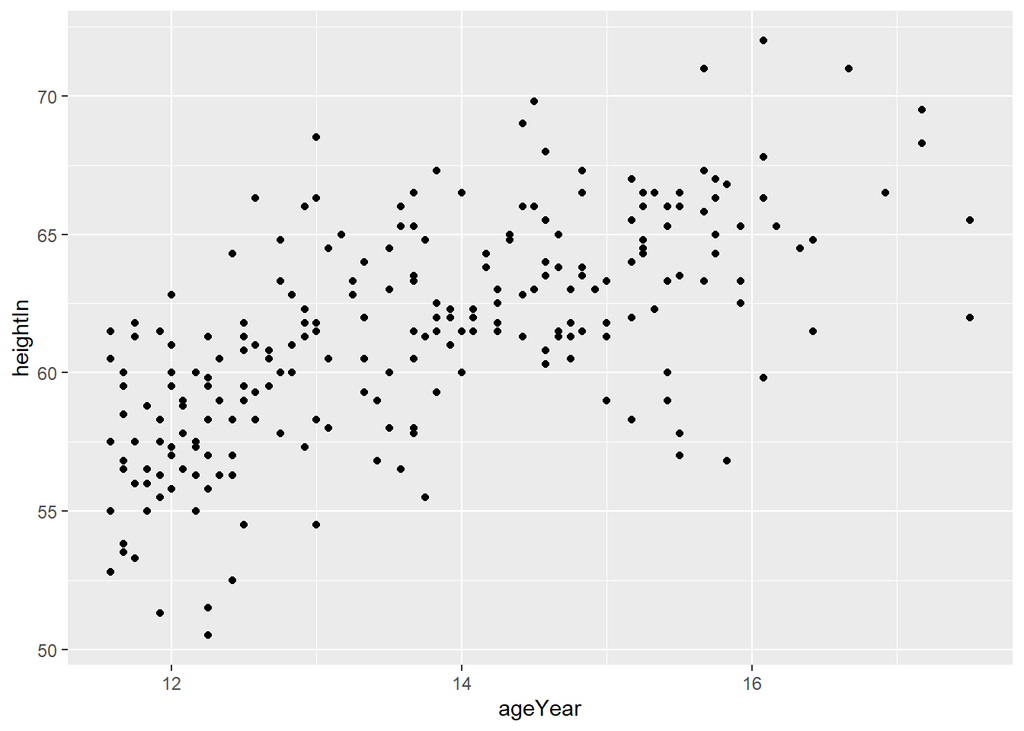

```r
ggplot(heightweight, aes(x = ageYear, y = heightIn)) +
  geom_point()
```

- `aes(x = ageYear, y = heightIn)`: maps the `ageYear` variable to the X-axis, and the `heightIn` variable to the Y-axis.
- `geom_point()`: adds a scatter plot layer, plotting individual data points to visualize the relationship between age and height.

## 8 Correlation chart: Color by group

### 8.1 Grouping Points by color or shape

This helps group variables to shape or color.

Here is an example using the `heightweight` dataset

```r
head(heightweight, 5)
```

```
  sex ageYear ageMonth heightIn weightLb
1   f   11.92      143     56.3     85.0
2   f   12.92      155     62.3    105.0
3   f   12.75      153     63.3    108.0
4   f   13.42      161     59.0     92.0
5   f   15.92      191     62.5    112.5
```

- `heightweight` dataset, which includes information about individuals’ age (ageYear), height (heightIn)

Plotting scatter plot with manually chosen color and shape

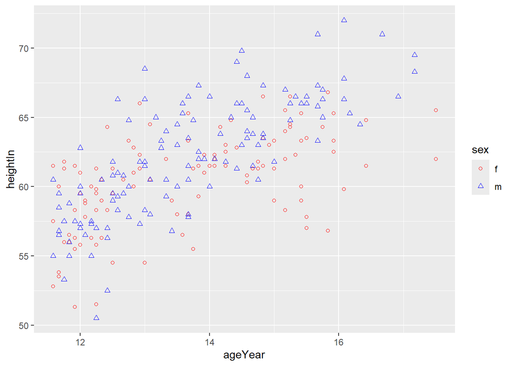

```r
ggplot(heightweight, aes(x = ageYear, y = heightIn, shape = sex, colour = sex)) +
  geom_point() +
  scale_shape_manual(values = c(1,2)) +
  scale_colour_manual(values = c("m" = "blue", "f" = "red"))
```

- `aes(shape = sex, colour = sex)`: Categorize gender `m` and `f` with color and shape
- `scale_shape_manual(values = c(1,2))`: Manually change the shape of gender
- `scale_colour_manual(values = c("m" = "blue", "f" = "red"))`: manually change the color of gender

## 9 Density chart

A density chart visualizes the distribution of a continuous variable as a smooth curve, highlighting patterns like peaks and spread.

### 9.1 Making a Basic Density Chart

Using the `ggplot2` library, the `geom_density` creates a density graph

Here is an example using the `faithful` dataset

```r
head(faithful, 5)
```

```
  eruptions waiting
1     3.600      79
2     1.800      54
3     3.333      74
4     2.283      62
5     4.533      85
```

- `faithful` dataset has two columns: `eruption`, `waiting`. Where it shows a relationship between eruption duration and waiting time

Graphing the density chart

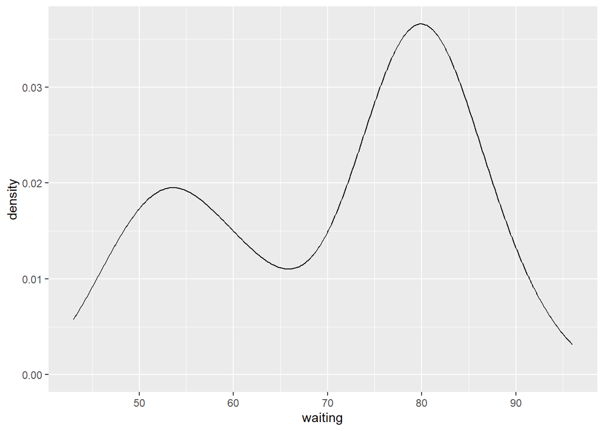

```r
ggplot(faithful, aes(x = waiting)) +
  geom_density()
```

- `aes(x = waiting)`: Maps the waiting variable to the X-axis. The density will be calculated based on this variable.
- `geom_density()`: The density plot visualizes the distribution of the waiting variable as a smooth curve

### 9.2 Multiple Density Chart

This allows for dencity curves with multiple groups of data

Example of this is plotted using `birthwt` dataset

```r
head(birthwt, 5)
```

```
   low age lwt race smoke ptl ht ui ftv  bwt
85   0  19 182    2     0   0  0  1   0 2523
86   0  33 155    3     0   0  0  0   3 2551
87   0  20 105    1     1   0  0  0   1 2557
88   0  21 108    1     1   0  0  1   2 2594
89   0  18 107    1     1   0  0  1   0 2600
```

First we need to modify the dataset to convert the smoke variable as a nameable factor.

```r
birthwtsmoke <- birthwt %>%
  mutate(smoke = as.factor(smoke))
```

- `birthwtsmoke <- birthwt %>%`: Copying the orginal dataset and renaming it to modify.

Plotting the multiple Density chart with different colors

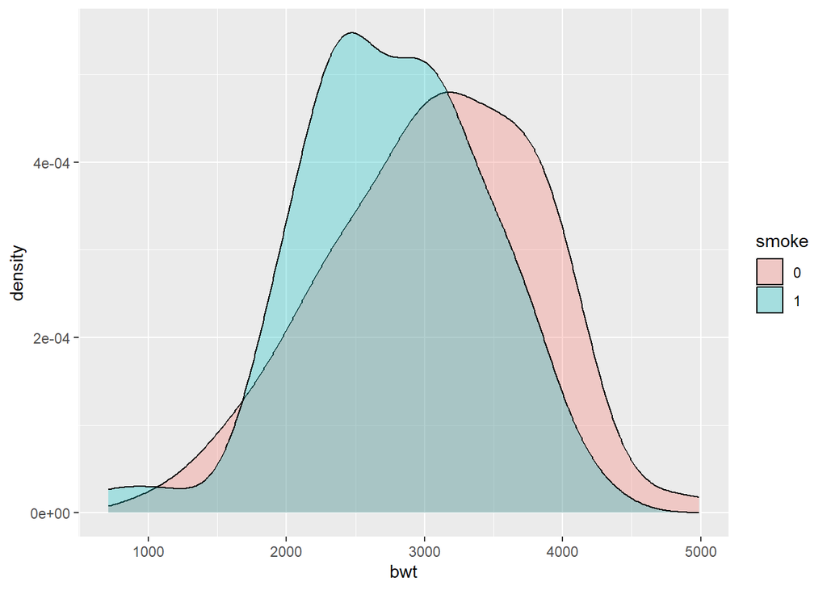

```r
ggplot(birthwtsmoke, aes(x = bwt, fill = smoke)) +
  geom_density(alpha = .3)
```

## 10 Boxplot

A box plot is used to summarize the distribution of a continuous variable, showing its median, quartiles, and potential outliers. It helps compare distributions across different groups and identify variations or anomalies in the data.

### 10.1 Creating a Basic Box plot

Using the `ggplot2` library, the `geom_boxplot` creates a boxplot graph

Here is an example using the `birthwt` dataset

```r
head(birthwt, 5)
```

```
   low age lwt race smoke ptl ht ui ftv  bwt
85   0  19 182    2     0   0  0  1   0 2523
86   0  33 155    3     0   0  0  0   3 2551
87   0  20 105    1     1   0  0  0   1 2557
88   0  21 108    1     1   0  0  1   2 2594
89   0  18 107    1     1   0  0  1   0 2600
```

- The two varibale used for the boxplot from the `birthwt` data set are:
  - bwt: Represents birth weight (the variable of interest for the box plot).
  - race: Represents the race category of the mother (used for grouping in the plot).

Graphing the box plot

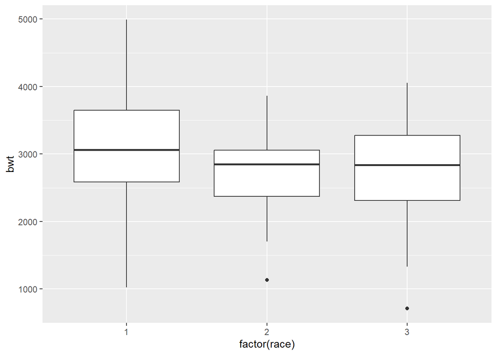

```r
ggplot(birthwt, aes(x = factor(race), y = bwt)) +
  geom_boxplot()
```

- `aes(x = factor(race), y = bwt)`: maps `race` to the X-axis as categorical groups and `bwt` to the Y-axis.
- `geom_boxplot()`:
  - Adds box plots to show the distribution of bwt for each race group.
  - The box shows the interquartile range, the line represents the median, and whiskers show the data range within 1.5 times the IQR. Outliers are displayed as dots.

### 10.2 Adding notches

Notches in a box plot represent a confidence interval around the median, helping to assess the variability of the median value.

Example

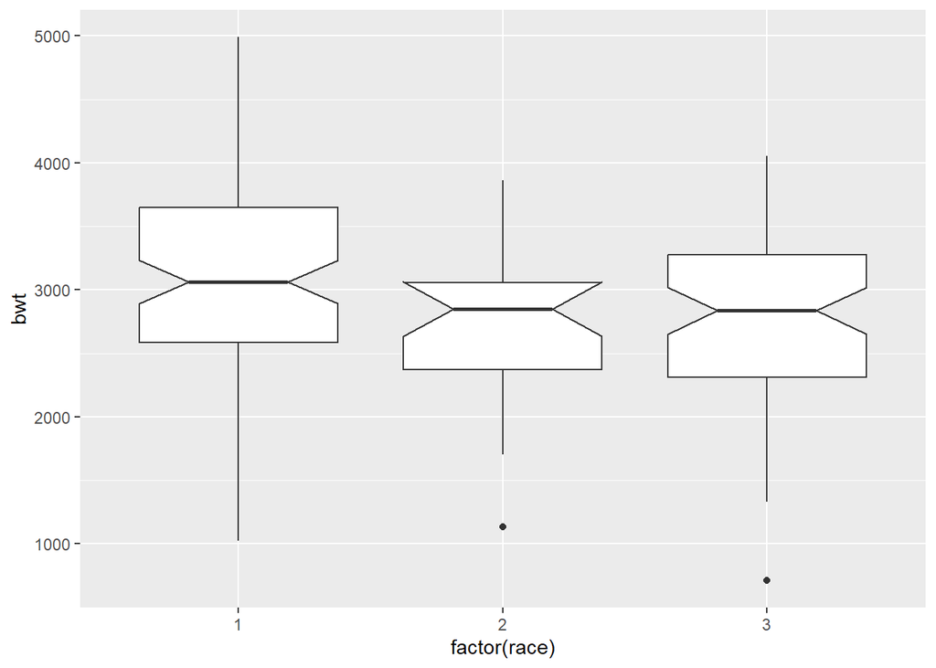

```r
ggplot(birthwt, aes(x = factor(race), y = bwt)) +
  geom_boxplot(notch = TRUE)
```

- `geom_boxplot(notch = TRUE)`: Adds notches to boxplots

## 11 Additional Universal Functions

### 11.1 Modifying label in the plot

Use `labs()` function to modify labels in the plot

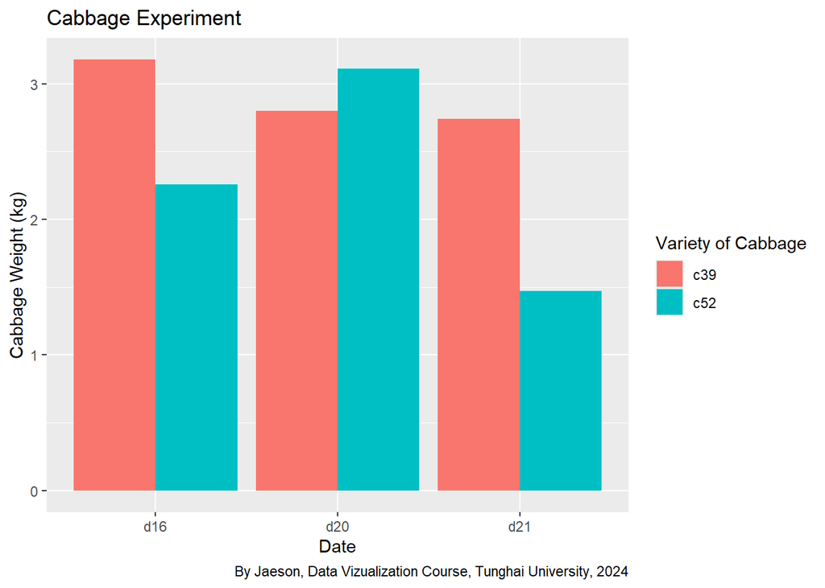

```r
ggplot(cabbage_exp, aes(x = Date, y = Weight, fill = Cultivar)) +
  labs(title='Cabbage Experiment',
       x = 'Date',
       y = 'Cabbage Weight (kg)',
       fill = 'Variety of Cabbage',
       caption = 'By Jaeson, Data Vizualization Course, Tunghai University, 2024')+
  geom_col(position = 'dodge')
```

- `labs()`: This function is used to modify the labels in the plot.
  - `title`: Sets the plot title.
  - `x`: Sets the label for the X-axis.
  - `y`: Sets the label for the Y-axis.
  - `fill`: Change the legend title.
  - `caption`: adds a caption label.

### 11.2 Changing the overall appearance

Use `theme()` function to change the overall appearance

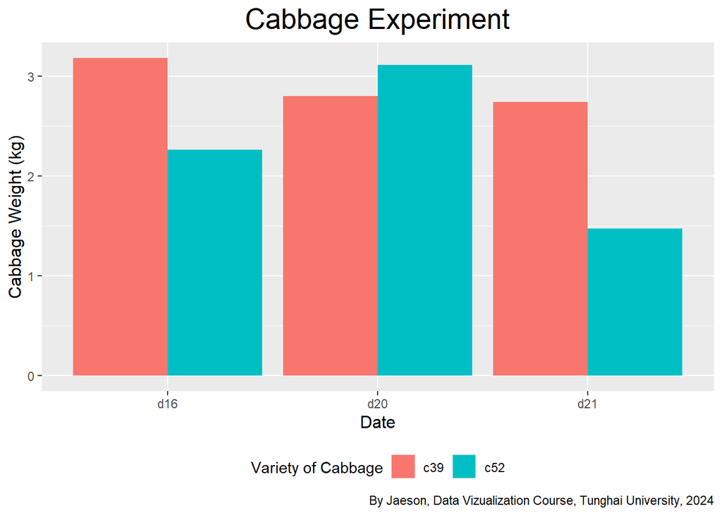

```r
ggplot(cabbage_exp, aes(x = Date, y = Weight, fill = Cultivar)) +
  labs(title='Cabbage Experiment',
       x = 'Date',
       y = 'Cabbage Weight (kg)',
       fill = 'Variety of Cabbage',
       caption = 'By Jaeson, Data Vizualization Course, Tunghai University, 2024')+
  geom_col(position = 'dodge')+
  theme(legend.position= "bottom",
        axis.title.x = element_text(size = 12),
        axis.title.y = element_text(size = 12),
        plot.title = element_text(hjust = 0.5, size=20))
```

### 11.3 Using predefined themes

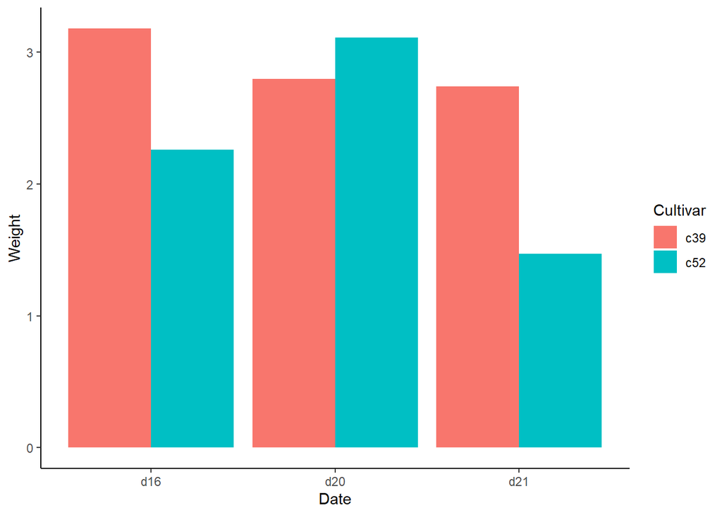

```r
ggplot(cabbage_exp, aes(x = Date, y = Weight, fill = Cultivar)) +
  geom_col(position = 'dodge')+
  theme_classic()
```

- `theme_classic()`: using one of the predefined themes